# looplot: Gallery of examples

Michael Kammer

2025-12-02

This vignette contains example annotated use-cases of the `looplot` package. We introduce several of the available options and briefly explain their effect. For an in-depth introduction into the goals of this package and the general workflow, see the vignette [“looplot: A package for creating nested loop plots”](https://matherealize.github.io/looplot_demo.html).

For many options to further customize the plots, please refer to the documentation of the underlying [ggplot2 package](https://ggplot2.tidyverse.org/index.html).

# 1 Example 1: general use-case

This example uses the same artifically created dataset as the other vignette.

## 1.1 Data

```r
set.seed(14)
params = list(
    samplesize = c(100, 200, 500),
    param1 = c(1, 2),
    param2 = c(1, 2, 3),
    param3 = c(1, 2, 3, 4)
)

design = expand.grid(params)

# add some "results"
design %<>%
    mutate(method1 = rnorm(n = n(),
                           mean = param1 * (param2 * param3 + 1000 / samplesize),
                           sd = 2),
           method2 = rnorm(n = n(),
                           mean = param1 * (param2 + param3 + 2000 / samplesize),
                           sd = 2),
           method3 = rnorm(n = n(),
                           mean = param1 * (param2 + param3 + 3000 / samplesize),
                           sd = 2))

knitr::kable(head(design, n = 10))
```

| samplesize | param1 | param2 | param3 | method1 | method2 | method3 |
| --- | --- | --- | --- | --- | --- | --- |
| 100 | 1 | 1 | 1 | 9.676300 | 22.984443 | 33.793024 |
| 200 | 1 | 1 | 1 | 9.437908 | 12.710978 | 17.636887 |
| 500 | 1 | 1 | 1 | 7.243334 | 6.225153 | 6.659465 |
| 100 | 2 | 1 | 1 | 24.994307 | 46.274059 | 62.983457 |
| 200 | 2 | 1 | 1 | 11.927719 | 22.866110 | 36.833710 |
| 500 | 2 | 1 | 1 | 8.463890 | 13.105232 | 14.311812 |
| 100 | 1 | 2 | 1 | 11.870238 | 22.974996 | 35.277654 |
| 200 | 1 | 2 | 1 | 9.137987 | 11.857579 | 18.394986 |
| 500 | 1 | 2 | 1 | 3.246069 | 5.631446 | 9.701592 |
| 100 | 2 | 2 | 1 | 26.086366 | 48.338618 | 65.184775 |

## 1.2 Basic facetted nested loop plot

- Define x-axis, grid facets and parameter step functions (`x`, `grid_rows`, `grid_cols`, `steps`).
- Adjust step positions (`steps_y_base`, `steps_y_height`).
- Set axis names (`x_name`, `y_name`).
- Adjust spacing between connected areas on the x-axis (`spu_x_shift`).
- Set color specifications via a function (`colors`).
- Adjust step annotations (`steps_values_annotate`, `steps_annotation_size`).
- Add a horizontal line with intercept 0 (`hline_intercept`).
- Expand the y-axis for proper display of the parameter step functions (`y_expand_add`).
- Rotate x-axis labels and adjust their position and size (`add_custom_theme`).

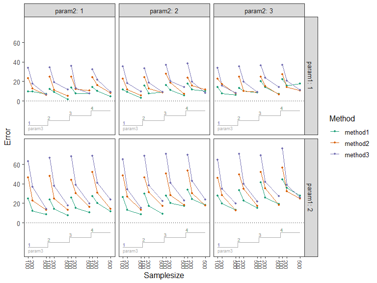

```r
p = nested_loop_plot(resdf = design,
                     x = "samplesize", steps = "param3",
                     grid_rows = "param1", grid_cols = "param2",
                     steps_y_base = -10, steps_y_height = 5,
                     x_name = "Samplesize", y_name = "Error",
                     spu_x_shift = 75,
                     colors = scales::brewer_pal(palette = "Dark2"),
                     steps_values_annotate = TRUE, steps_annotation_size = 2.5,
                     hline_intercept = 0,
                     y_expand_add = c(10, NULL),
                     post_processing = list(
                         add_custom_theme = list(
                             axis.text.x = element_text(angle = -90,
                                                        vjust = 0.5,
                                                        size = 8)
                         )
                     ))
print(p)
```

## 1.3 Only rows

- Only set `grid_rows` argument, move other parameters into `steps`.
- Re-adjust steps positions.

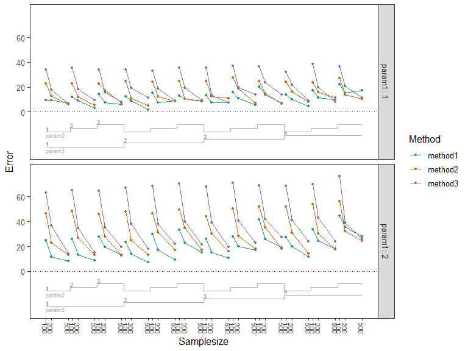

```r
p = nested_loop_plot(resdf = design,
                     x = "samplesize", steps = c("param2", "param3"),
                     grid_rows = "param1",
                     steps_y_base = -10, steps_y_height = 3, steps_y_shift = 3,
                     x_name = "Samplesize", y_name = "Error",
                     spu_x_shift = 75,
                     colors = scales::brewer_pal(palette = "Dark2"),
                     steps_values_annotate = TRUE, steps_annotation_size = 2.5,
                     hline_intercept = 0,
                     y_expand_add = c(10, NULL),
                     post_processing = list(
                         add_custom_theme = list(
                             axis.text.x = element_text(angle = -90,
                                                        vjust = 0.5,
                                                        size = 8)
                         )
                     ))
print(p)
```

## 1.4 Only columns

- Only set `grid_cols` argument, move other parameters into `steps`.
- Re-ajust steps positions.

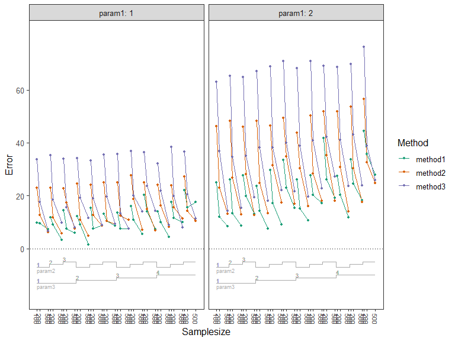

```r
p = nested_loop_plot(resdf = design,
                     x = "samplesize", steps = c("param2", "param3"),
                     grid_cols = "param1",
                     steps_y_base = -5, steps_y_height = 1, steps_y_shift = 3,
                     x_name = "Samplesize", y_name = "Error",
                     spu_x_shift = 75,
                     colors = scales::brewer_pal(palette = "Dark2"),
                     steps_values_annotate = TRUE, steps_annotation_size = 2.5,
                     hline_intercept = 0,
                     y_expand_add = c(10, NULL),
                     post_processing = list(
                         add_custom_theme = list(
                             axis.text.x = element_text(angle = -90,
                                                        vjust = 0.5,
                                                        size = 8)
                         )
                     ))
print(p)
```

## 1.5 “Classic” nested loop plots

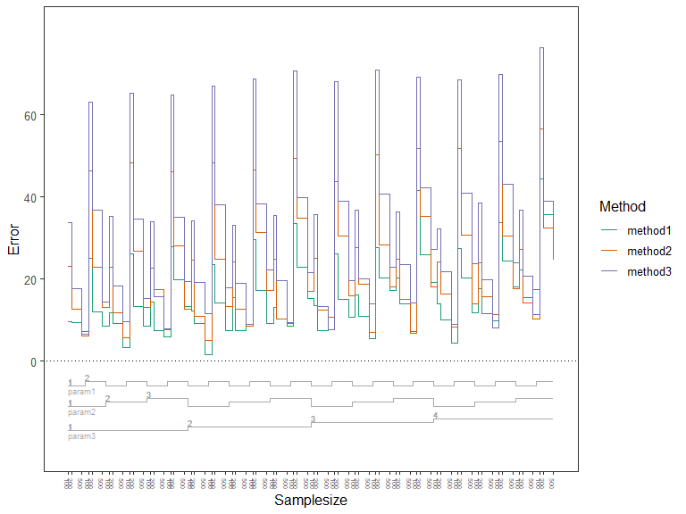

```r
p = nested_loop_plot(resdf = design,
                     x = "samplesize", steps = c("param1", "param2", "param3"),
                     draw = "add_steps",
                     steps_y_base = -5, steps_y_height = 1, steps_y_shift = 3,
                     x_name = "Samplesize", y_name = "Error",
                     spu_x_shift = 200,
                     connect_spus = TRUE,
                     colors = scales::brewer_pal(palette = "Dark2"),
                     steps_values_annotate = TRUE, steps_annotation_size = 2.5,
                     hline_intercept = 0,
                     y_expand_add = c(10, NULL),
                     post_processing = list(
                         add_custom_theme = list(
                             axis.text.x = element_text(angle = -90,
                                                        vjust = 0.5,
                                                        size = 5)
                         )
                     ))
print(p)
```

## 1.6 Spacing on x-axis

So far the x-axis has been treated as numeric scale with spacing of the breaks according to the values of the design parameter which defines the x-axis. If the design parameter is actually a factor, or converted to be one, then the spacing on the x-axis is equal.

- Input data.frame for `nested_loop_plot` now uses a factor as x-axis (converted via `dplyr::mutate`).
- Adapt gap between different connected areas of the plot (spu) via `spu_x_shift`. Note that the gap between any two datapoints on the x-axis is now exactly one unit.

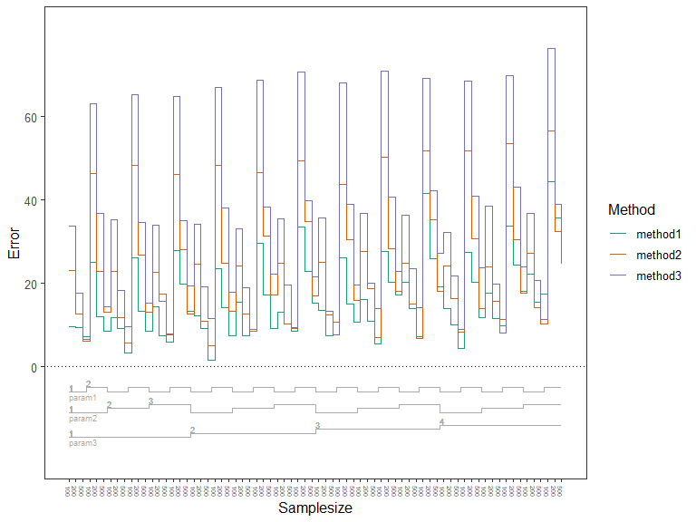

```r
x_factor_design = design %>%
    mutate(samplesize = as.factor(samplesize))
p = nested_loop_plot(resdf = x_factor_design,
                     x = "samplesize", steps = c("param1", "param2", "param3"),
                     draw = "add_steps",
                     steps_y_base = -5, steps_y_height = 1, steps_y_shift = 3,
                     x_name = "Samplesize", y_name = "Error",
                     spu_x_shift = 1,
                     connect_spus = TRUE,
                     colors = scales::brewer_pal(palette = "Dark2"),
                     steps_values_annotate = TRUE, steps_annotation_size = 2.5,
                     hline_intercept = 0,
                     y_expand_add = c(10, NULL),
                     post_processing = list(
                         add_custom_theme = list(
                             axis.text.x = element_text(angle = -90,
                                                        vjust = 0.5,
                                                        size = 5)
                         )
                     ))
print(p)
```

## 1.7 Re-labelling data

Data can be re-labelled to streamline the display of parameters on the x-axis or give meaningful names to panels.

- Relabel data using `replace_labels`.

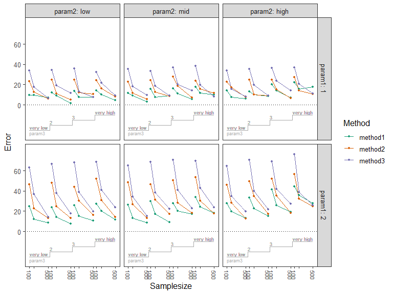

```r
p = nested_loop_plot(resdf = design,
                     x = "samplesize", steps = "param3",
                     grid_rows = "param1", grid_cols = "param2",
                     steps_y_base = -10, steps_y_height = 5,
                     x_name = "Samplesize", y_name = "Error",
                     spu_x_shift = 75,
                     colors = scales::brewer_pal(palette = "Dark2"),
                     steps_values_annotate = TRUE, steps_annotation_size = 2.5,
                     hline_intercept = 0,
                     y_expand_add = c(10, NULL),
                     replace_labels = list(
                         samplesize = c("100$" = "100",
                                        "200$" = "",
                                        "500$" = "500"),
                         param2 = c("1" = "low",
                                    "2" = "mid",
                                    "3" = "high"),
                         param3 = c("1" = "very low",  # partial replacement
                                    "4" = "very high")
                     ),
                     post_processing = list(
                         add_custom_theme = list(
                             axis.text.x = element_text(angle = -90,
                                                        vjust = 0.5,
                                                        size = 8)
                         )
                     ))
print(p)
```

## 1.8 Changing and adding design elements

Elements of the plot can be customized. Note that these parameters (`sizes`, `line_linetypes`, `point_shapes`, `colors`) all at least take either a single numeric value, a vector of numeric values or a named vector of numeric values specifying which method should have which value.

- Provide different linetpyes per method (`line_linetypes`).
- Provide different point shapes per method (`point_shapes`).
- Provide different point sizes per method. This requires passing a numeric vector to `sizes` and setting `point_size` to `NULL` due to the underlying implementation in the `ggplot2` package.
- Fixing linewidth to 1 (`line_size`).
- Add a ribbon around zero, .e.g to indicate confidence regions, simulation monte carlo error or a target region the methods should reach (added to post-processing list via `add_annotation`).

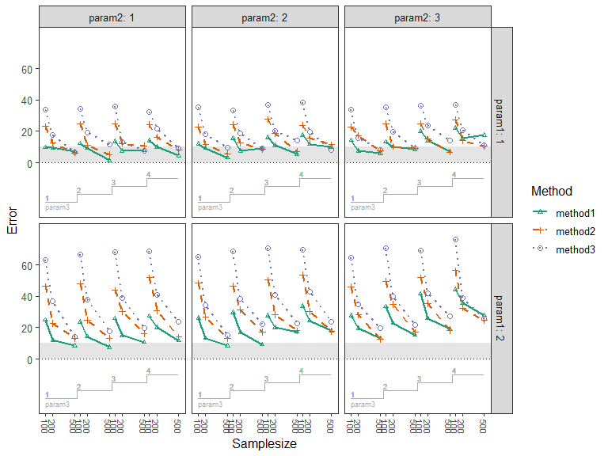

```r
p = nested_loop_plot(resdf = design,
                     x = "samplesize", steps = "param3",
                     grid_rows = "param1", grid_cols = "param2",
                     steps_y_base = -10, steps_y_height = 5,
                     x_name = "Samplesize", y_name = "Error",
                     spu_x_shift = 75,
                     colors = scales::brewer_pal(palette = "Dark2"),
                     line_linetypes = c(1, 2, 3),
                     point_shapes = c("method1" = 2, "method2" = 3, "method3" = 1),
                     sizes = c(1, 1.5, 2), point_size = NULL,
                     line_size = 1,
                     steps_values_annotate = TRUE, steps_annotation_size = 2.5,
                     hline_intercept = 0,
                     y_expand_add = c(10, NULL),
                     post_processing = list(
                         # add ribbon via an annotation
                         add_annotation = list(
                             geom = "rect",
                             xmin = -Inf, xmax = Inf, # stretch whole x-axis
                             ymin = 0, ymax = 10, alpha = 0.1, fill = "black"
                         ),
                         add_custom_theme = list(
                             axis.text.x = element_text(angle = -90,
                                                        vjust = 0.5,
                                                        size = 8)
                         )
                     ))
print(p)
```

## 1.9 Partial designs

In a partial design, not every possible combination of values for the design parameters is present in the results from the experiment. In our example, we simply remove parts corresponding to two design parameters from the data.frame containing the data.

- The `design_type` can be set to “partial” to remove the parameter step functions for the missing design parts. If left at default (“full”), then the missing parts are added.

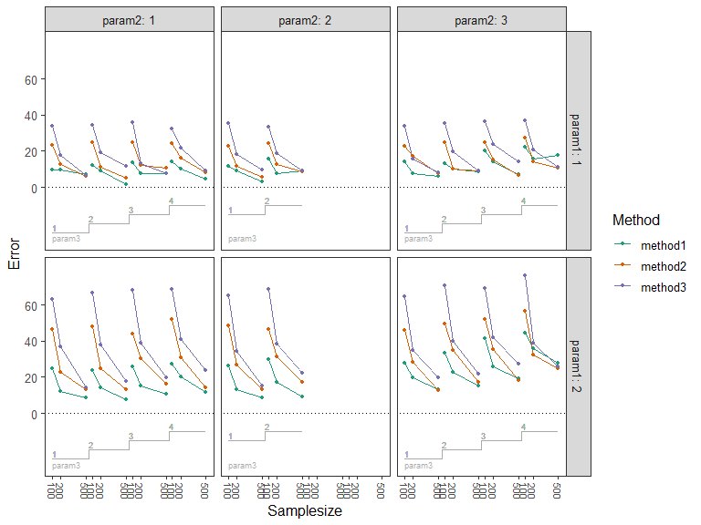

```r
partial_design = design %>%
    filter(!(param2 == 2 & param3 %in% c(3, 4)))
p = nested_loop_plot(resdf = partial_design,
                     x = "samplesize", steps = "param3",
                     grid_rows = "param1", grid_cols = "param2",
                     steps_y_base = -10, steps_y_height = 5,
                     x_name = "Samplesize", y_name = "Error",
                     design_type = "partial",
                     spu_x_shift = 75,
                     colors = scales::brewer_pal(palette = "Dark2"),
                     steps_values_annotate = TRUE, steps_annotation_size = 2.5,
                     hline_intercept = 0,
                     y_expand_add = c(10, NULL),
                     post_processing = list(
                         add_custom_theme = list(
                             axis.text.x = element_text(angle = -90,
                                                        vjust = 0.5,
                                                        size = 8)
                         )
                     ))
print(p)
```

An alternative parameter to use in case of missing data due to partial designs determines how “holes” in the data are handled.

- The `na_rm` argument can be set to TRUE (default) to ignore missing data when connecting result values. (Note that in the middle panel no data is available for samplesize 200.)

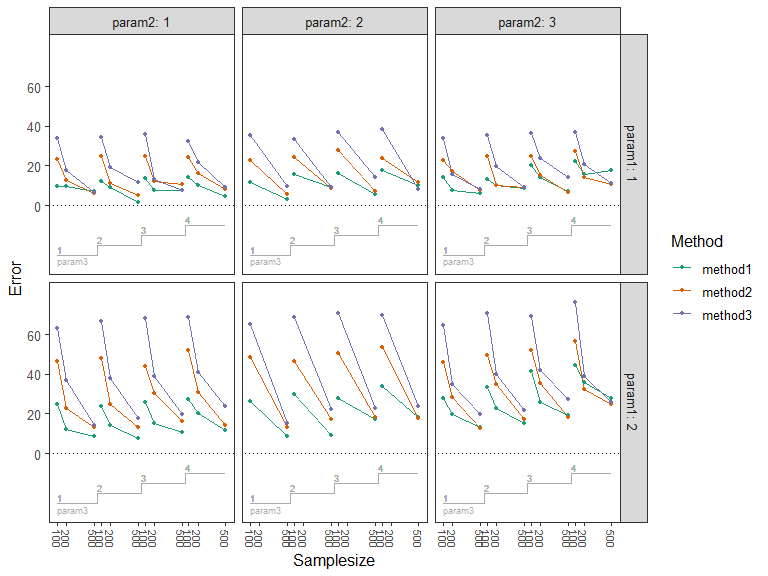

```r
partial_design = design %>%
    filter(!(param2 == 2 & samplesize == 200))
p = nested_loop_plot(resdf = partial_design,
                     x = "samplesize", steps = "param3",
                     grid_rows = "param1", grid_cols = "param2",
                     steps_y_base = -10, steps_y_height = 5,
                     x_name = "Samplesize", y_name = "Error",
                     na_rm = TRUE,
                     spu_x_shift = 75,
                     colors = scales::brewer_pal(palette = "Dark2"),
                     steps_values_annotate = TRUE, steps_annotation_size = 2.5,
                     hline_intercept = 0,
                     y_expand_add = c(10, NULL),
                     post_processing = list(
                         add_custom_theme = list(
                             axis.text.x = element_text(angle = -90,
                                                        vjust = 0.5,
                                                        size = 8)
                         )
                     ))
print(p)
```

- The `na_rm` argument can be set to FALSE make it clear that data is missing by not connecting the result values accross missing data.

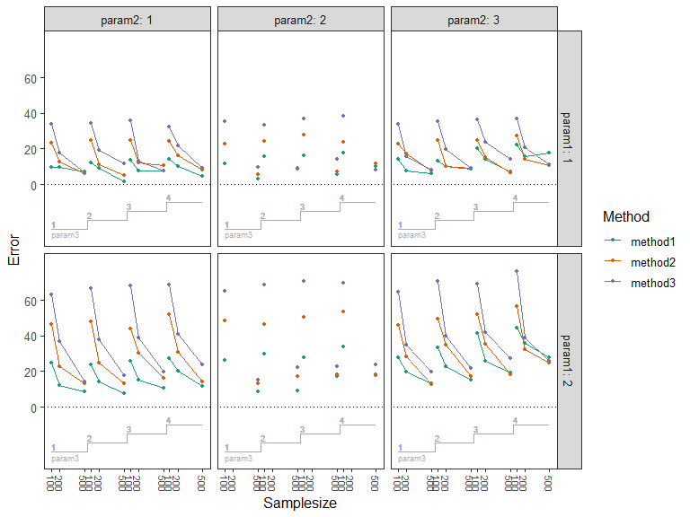

```r
partial_design = design %>%
    filter(!(param2 == 2 & samplesize == 200))
p = nested_loop_plot(resdf = partial_design,
                     x = "samplesize", steps = "param3",
                     grid_rows = "param1", grid_cols = "param2",
                     steps_y_base = -10, steps_y_height = 5,
                     x_name = "Samplesize", y_name = "Error",
                     na_rm = FALSE,
                     spu_x_shift = 75,
                     colors = scales::brewer_pal(palette = "Dark2"),
                     steps_values_annotate = TRUE, steps_annotation_size = 2.5,
                     hline_intercept = 0,
                     y_expand_add = c(10, NULL),
                     post_processing = list(
                         add_custom_theme = list(
                             axis.text.x = element_text(angle = -90,
                                                        vjust = 0.5,
                                                        size = 8)
                         )
                     ))
print(p)
```

## 1.10 Free axes and axis adjustments

Axes of the facets can have different scales. However, currently it is only possible to have different y- and x-scales for each row and column, respectively. This is made possible thanks to the [`facet_grid_sc`](https://github.com/zeehio/facetscales) extension of `ggplot2`. Because of this, it is also possible to adjust the axes individually (i.e. per row / per column).

- Set `grid_scales` argument to “free_y” to free the y-scale. The x-axis remains the same, even if set to be free.
- Adjust y-axis only in second row by passing a list to `y_expand_add` (entries of this list are named by the values of the design parameter which defines the `grid_rows`).

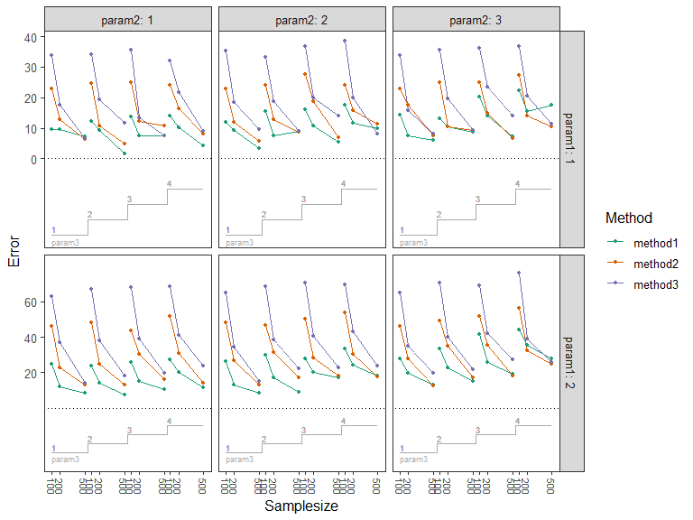

```r
p = nested_loop_plot(resdf = design,
                     x = "samplesize", steps = "param3",
                     grid_rows = "param1", grid_cols = "param2",
                     steps_y_base = -10, steps_y_height = 5,
                     x_name = "Samplesize", y_name = "Error",
                     grid_scales = "free_y",
                     spu_x_shift = 75,
                     colors = scales::brewer_pal(palette = "Dark2"),
                     steps_values_annotate = TRUE, steps_annotation_size = 2.5,
                     hline_intercept = 0,
                     y_expand_add = list(
                         "2" = c(10, NULL)
                     ),
                     post_processing = list(
                         add_custom_theme = list(
                             axis.text.x = element_text(angle = -90,
                                                        vjust = 0.5,
                                                        size = 8)
                         )
                     ))
print(p)
```

## 1.11 Addtional data display

The package supports adding steps for meta-information. These do not influence the layout of the plot.

- Additional steps are added via `steps_add` (note that additional column added to the design data.frame).

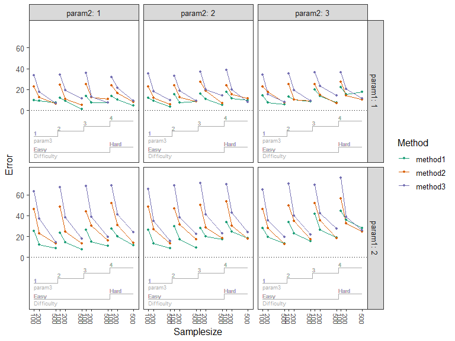

```r
meta_design = design %>%
    mutate(Difficulty = if_else(param3 == 4, "Hard", "Easy"))
p = nested_loop_plot(resdf = meta_design,
                     x = "samplesize", steps = "param3",
                     grid_rows = "param1", grid_cols = "param2",
                     steps_add = "Difficulty",
                     steps_y_base = -10, steps_y_height = 5, steps_y_shift = 10,
                     x_name = "Samplesize", y_name = "Error",
                     spu_x_shift = 75,
                     colors = scales::brewer_pal(palette = "Dark2"),
                     steps_values_annotate = TRUE, steps_annotation_size = 2.5,
                     hline_intercept = 0,
                     y_expand_add = c(10, NULL),
                     post_processing = list(
                         add_custom_theme = list(
                             axis.text.x = element_text(angle = -90,
                                                        vjust = 0.5,
                                                        size = 8)
                         )
                     ))
print(p)
```

## 1.12 Adding geometries to the plot

Further geometries can be added to the plot via post-processing. For several simple geometries convenience wrapper functions are implented in this package (all starting with `add_`) so that only the parameters of the geometry need to be passed to post-processing. However, arbitrary geometries are supported via the `add_geom_at_position` wrapper function, which allows the user to directly pass any geometry object.

Here we add text to annotate the results, but also additional points or lines could be drawn in the same way. By passing a new data.frame, even new data can be added in this step. Examples for such advanced usage are shown below for adding panel specific geometries or using this package in a modularl fashion.

- Annotate results by adding labels to them in post-processing (`add_text`).
- Add ribbons behind the other geometries to highlight areas of the plot via `add_geom_at_position` (note that `inherit.aes` is set to FALSE so that the rest of the plot does not impact the ribbons).

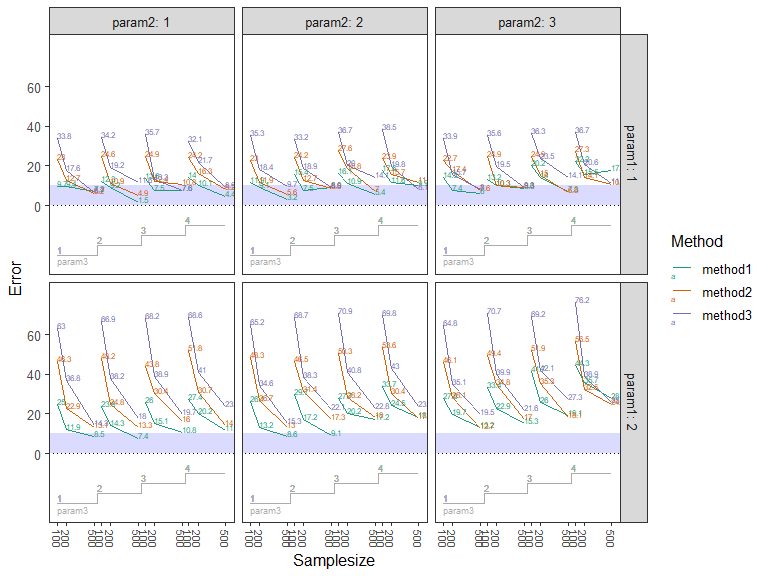

```r
p = nested_loop_plot(resdf = design,
                     x = "samplesize", steps = "param3",
                     grid_rows = "param1", grid_cols = "param2",
                     steps_y_base = -10, steps_y_height = 5,
                     x_name = "Samplesize", y_name = "Error",
                     draw = "add_lines",
                     spu_x_shift = 75,
                     colors = scales::brewer_pal(palette = "Dark2"),
                     steps_values_annotate = TRUE, steps_annotation_size = 2.5,
                     hline_intercept = 0,
                     y_expand_add = c(10, NULL),
                     post_processing = list(
                         add_text = list(
                             decimals = 1, size = 2, vjust = 0, hjust = 0
                         ),
                         add_geom_at_position = list(
                             g = geom_rect(
                                 data = NULL,
                                 xmin = -Inf, xmax = Inf,
                                 ymin = 0, ymax = 10,
                                 alpha = 0.005, fill = "blue",
                                 linetype = "blank",
                                 inherit.aes = FALSE
                             ),
                             position = "bottom" # place below other geometries
                         ),
                         add_custom_theme = list(
                             axis.text.x = element_text(angle = -90,
                                                        vjust = 0.5,
                                                        size = 8)
                         )
                     ))
print(p)
```

## 1.13 Axis transformations

The normal axis transformations of `ggplot2` can not be used in general as the steps added for simulation parameters are also on the same y-scale as the simulation results. E.g. if a logarithmic scale is to be used for results, but the parameter steps have negative y-coordinates, then the approach using `ggplot2` will not work.

Hence, the functionality is implemented by transformation of the data. This can be done by the user outside the `looplot` package or passed to the functions implemented in this package using the `trans` argument.

Note that this is a transformation of the data. Hence, the y-axis labels are also on the transformed scale. If that is not wanted, the user can easily reverse this transformation for the labels by passing a function to the `y_labels` argument. See documentation. Another possibility is to simply rename the y-axis as e.g. ‘log2 of results’ to indicate the scaling.

A further consequence is that all additions to the plot such as lines or parameter steps are now also on the transformed scale and may require re-adjustment.

- Define transformation by setting `trans`.
- Set `ylim`, `y_breaks` and `y_labels` arguments.
- Adjust parameter step functions and y-axis expansion for proper display.

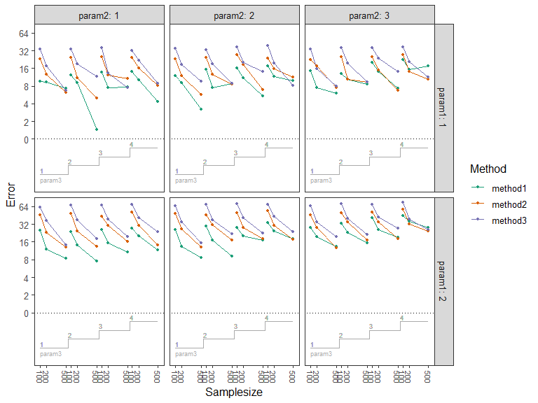

```r
p = nested_loop_plot(resdf = design,
                     x = "samplesize", steps = "param3",
                     grid_rows = "param1", grid_cols = "param2",
                     steps_y_base = -0.5, steps_y_height = 0.5,
                     x_name = "Samplesize", y_name = "Error",
                     trans = log2,
                     ylim = c(0, 6),
                     y_breaks = 0:6,
                     y_labels = function(x) ifelse(x > 0, 2^x, 0),
                     spu_x_shift = 75,
                     colors = scales::brewer_pal(palette = "Dark2"),
                     steps_values_annotate = TRUE, steps_annotation_size = 2.5,
                     hline_intercept = 0,
                     y_expand_add = c(3, 0.5),
                     post_processing = list(
                         add_custom_theme = list(
                             axis.text.x = element_text(angle = -90,
                                                        vjust = 0.5,
                                                        size = 8)
                         )
                     ))
print(p)
```

# 2 Example 2: many design parameter

## 2.1 Data

We expand the design parameters by another layer of parameters. Overall the setup contains 600 unique parameter combinations.

```r
set.seed(82356)
params = list(
    samplesize = c(10, 50, 100, 200, 500),
    param1 = c(1, 2),
    param2 = c(1, 2, 3),
    param3 = c(1, 2, 3, 4),
    param4 = c(1, 2, 3, 4, 5)
)

design = expand.grid(params)

design %<>%
    mutate(method1 = rnorm(n = n(),
                           mean = param1 * (param2 * param3 * param4 + 50 / samplesize),
                           sd = 2),
           method2 = rnorm(n = n(),
                           mean = param1 * (param2 + param3 + param4 + 100 / samplesize),
                           sd = 2),
           method3 = rnorm(n = n(),
                           mean = param1 * (param2 + param3 * param4 + 150 / samplesize),
                           sd = 2))

knitr::kable(head(design, n = 10))
```

| samplesize | param1 | param2 | param3 | param4 | method1 | method2 | method3 |
| --- | --- | --- | --- | --- | --- | --- | --- |
| 10 | 1 | 1 | 1 | 1 | 4.4014514 | 16.411023 | 17.6199471 |
| 50 | 1 | 1 | 1 | 1 | 0.2362822 | 5.111114 | 6.6717133 |
| 100 | 1 | 1 | 1 | 1 | -2.5726311 | 2.753999 | 3.5378787 |
| 200 | 1 | 1 | 1 | 1 | 3.1213877 | 4.181095 | 0.1538609 |
| 500 | 1 | 1 | 1 | 1 | 2.6420683 | 5.497084 | 3.5507153 |
| 10 | 2 | 1 | 1 | 1 | 11.8447059 | 27.180114 | 35.4790589 |
| 50 | 2 | 1 | 1 | 1 | 3.6258356 | 10.845427 | 9.3207731 |
| 100 | 2 | 1 | 1 | 1 | 5.0769028 | 8.175888 | 9.4723016 |
| 200 | 2 | 1 | 1 | 1 | 3.8329818 | 7.640888 | 5.8487234 |
| 500 | 2 | 1 | 1 | 1 | 2.1029934 | 5.666710 | 5.9034683 |

## 2.2 Plots

- Set x-axis labels to NULL to avoid cluttering display (`x_labels`). Add values on x-axis to name of axis.

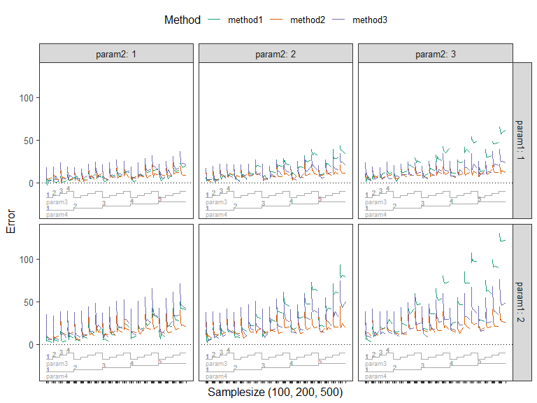

```r
p = nested_loop_plot(resdf = design,
                     x = "samplesize", steps = c("param3", "param4"),
                     grid_rows = "param1", grid_cols = "param2",
                     steps_y_base = -10, steps_y_height = 2.5, steps_y_shift = 5,
                     x_name = "Samplesize (100, 200, 500)", y_name = "Error",
                     draw = "add_lines",
                     spu_x_shift = 75,
                     colors = scales::brewer_pal(palette = "Dark2"),
                     steps_values_annotate = TRUE, steps_annotation_size = 2.5,
                     hline_intercept = 0,
                     y_expand_add = c(10, NULL),
                     x_labels = NULL,
                     post_processing = list(
                         add_custom_theme = list(legend.position = "top")
                     ))
print(p)
```

- Add grid lines as in Rücker and Schwarzer (2014) (adjust theme in `add_custom_theme`).

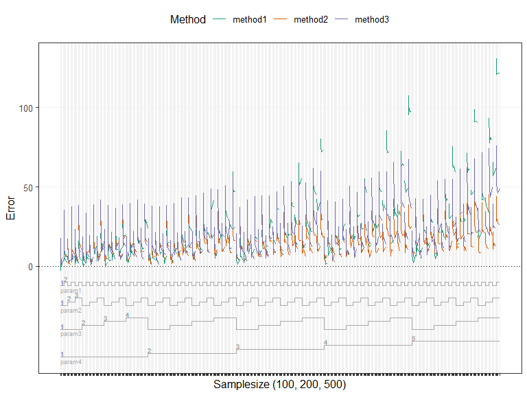

```r
p = nested_loop_plot(resdf = design,
                     x = "samplesize", steps = c("param1", "param2", "param3", "param4"),
                     steps_y_base = -10, steps_y_height = 2.5, steps_y_shift = 7.5,
                     x_name = "Samplesize (100, 200, 500)", y_name = "Error",
                     draw = "add_lines",
                     spu_x_shift = 75,
                     colors = scales::brewer_pal(palette = "Dark2"),
                     steps_values_annotate = TRUE, steps_annotation_size = 2.5,
                     hline_intercept = 0,
                     y_expand_add = c(10, NULL),
                     x_labels = NULL,
                     post_processing = list(
                         add_custom_theme = list(
                             legend.position = "top",
                             panel.grid.major = element_line(
                                 color = "grey95", size = 0.1
                             )
                         )
                     ))
print(p)
```

# 3 Advanced usage

## 3.1 Panel specific decorations

Annotations may depend on the design factors of the simulation study. For example, variability or highlighted regions in the plot may be indicated by ribbons, which in turn may depend on the column variable of the facets. To add such panel parameter specific decorations we can use the following  
approach. We demonstrate them by recreating panel specific ribbons. Data is created in the same way as in the first example.

- Augment the initial data matrix by additional columns which specify panel-wise parameters for the geometries to add by using `dplyr::case_when`.
- Use `pass_through` argument of the `nested_loop_plot` function to pass the augmented columns untouched to post-processing. They leave the rest of the plot completely unaffected.
- Add geometries that work with the columns that were passed through. For that we use the `add_geom_at_position` function in post-processing and make sure to set `inherit.aes` to FALSE (otherwise the legend may be affected by the new geometries).

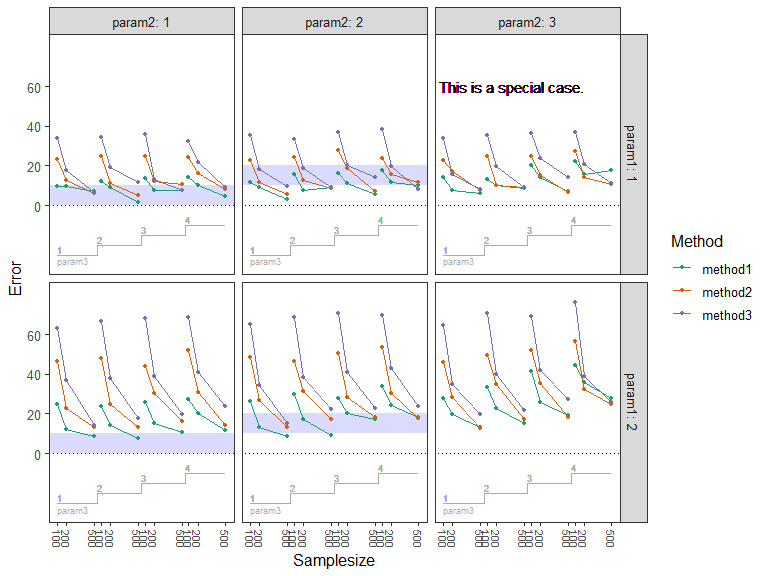

```r
# augment design data
augmented_design = design %>% mutate(
    ymin = case_when(param2 == 1 ~ 0,
                     param2 == 2 ~ 10),
    ymax = case_when(param2 == 1 ~ 10,
                     param2 == 2 ~ 20),
    note = case_when(param2 == 3 & param1 == 1 ~ "This is a special case.")
)

p = nested_loop_plot(resdf = augmented_design,
                     x = "samplesize", steps = "param3",
                     grid_rows = "param1", grid_cols = "param2",
                     # pass data to post-processing
                     pass_through = c("ymin", "ymax", "note"),
                     steps_y_base = -10, steps_y_height = 5,
                     x_name = "Samplesize", y_name = "Error",
                     draw = c("add_points", "add_lines"),
                     spu_x_shift = 75,
                     colors = scales::brewer_pal(palette = "Dark2"),
                     steps_values_annotate = TRUE, steps_annotation_size = 2.5,
                     hline_intercept = 0,
                     y_expand_add = c(10, NULL),
                     post_processing = list(
                         # add geometries that use the passed through data
                         # add panel specific text
                         add_geom_at_position = list(
                             geom = geom_text(
                                 aes(x = 50, y = 60, label = note),
                                 size = 4, color = "black",
                                 hjust = 0,
                                 inherit.aes = FALSE)
                         ),
                         # add panel specific ribbons
                         add_geom_at_position = list(
                             geom = geom_rect(
                                 aes(ymin = ymin, ymax = ymax),
                                 xmin = -Inf, xmax = Inf,
                                 alpha = 0.005, fill = "blue",
                                 linetype = "blank",
                                 inherit.aes = FALSE
                             ),
                             position = "bottom" # place below other geometries
                         ),
                         add_custom_theme = list(
                             axis.text.x = element_text(angle = -90,
                                                        vjust = 0.5,
                                                        size = 8)
                         )
                     ))

print(p)
```

Similar results can also be obtained when working with the package in a modular fashion, as demonstrated below.

## 3.2 Modular use of the package

While the main interface to this package is a single function, the creation of nested loop plots is actually implemented via modular functions. This is useful if the user wants more control over the design of the plot and especially if additional meta-data should be added.

We recreate the basic facetted nested loop plot using the same data step by step. These are

- Creation of basic plotting data via `nested_loop_base_data`. This data.frame contains all information to create the nested loop plots from this package, except for the data for drawing design parameter step functions. It can be used to add further information for plotting.
- Creation of a basic `ggplot2` object via `nested_loop_base_plot`. It does not contain design parameter step functions.
- Addition of data for drawing parameter step functions via `nested_loop_paramsteps_data`.
- Updating the `ggplot2` object for drawing parameter step functions.
- Add post-processing to the `ggplot2` object to adjust scales and axes.

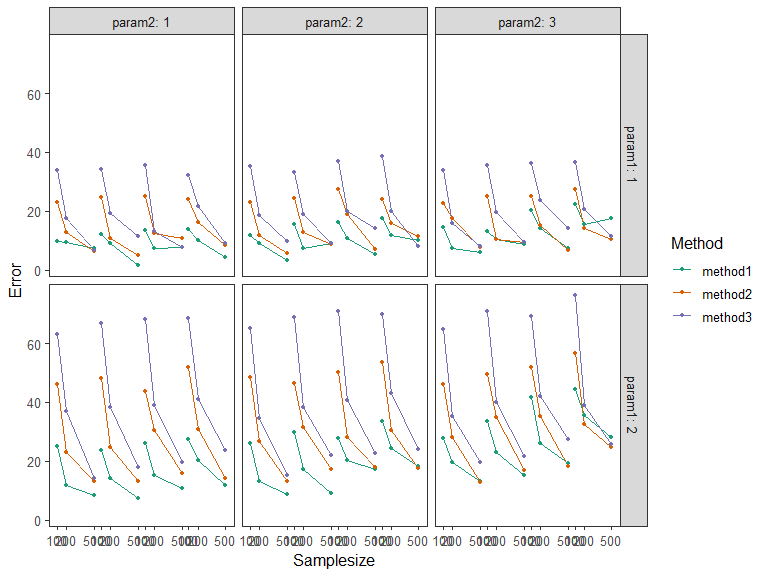

```r
plot_data = nested_loop_base_data(
    design,
    x = "samplesize", steps = "param3",
    grid_rows = "param1", grid_cols = "param2",
    spu_x_shift = 75
)

p = nested_loop_base_plot(
    plot_data,
    x_name = "Samplesize",
    y_name = "Error",
    colors = scales::brewer_pal(palette = "Dark2")
)
print(p)
```

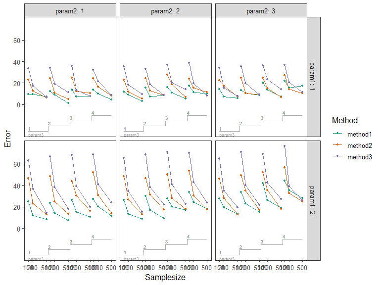

```r
plot_data = nested_loop_paramsteps_data(
    plot_data,
    steps_y_base = -10,
    steps_y_height = 5
)

p = nested_loop_paramsteps_plot(
    p, plot_data,
    steps_values_annotate = TRUE,
    steps_annotation_size = 2.5
)
print(p)
```

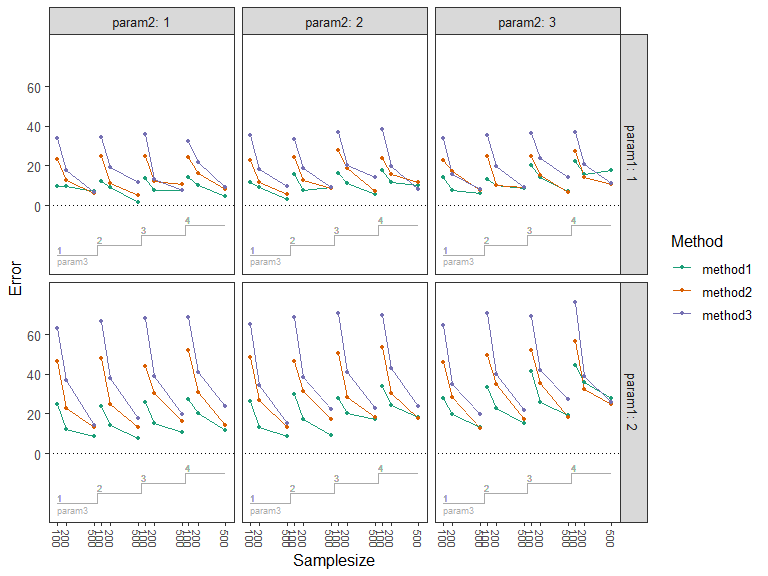

```r
p = add_processing(
    p,
    list(
        # set limits
        adjust_ylim = list(
            y_expand_add = c(10, NULL)
        ),
        # adjust theme
        add_custom_theme = list(
            axis.text.x = element_text(angle = -90,
                                       vjust = 0.5,
                                       size = 8)
        ),
        # add horizontal lines
        add_abline = list(
            intercept = 0
        )
    )
)
print(p)
```

## 3.3 Customizing plots

Using the package functions modularly opens up many more options for customization. These are all based on modification of the data.frames which are returned by `nested_loop_base_data` and `nested_loop_paramsteps_data` that provide the basis data for the plotting functions of this package.

We demonstrate an exemplary customization here. First, we obtain the necessary data. The data.frame of interest is stored in the `plotdf` entry of the resulting list, which can be modified to add meta-information to the plots. We do this using the `dplyr::mutate` and `dplyr::case_when` functionality.

- Annotate scenarios of special interest, e.g. due especially interesting combination of design parameters. Here we indicate scenarios with samplesize of 100 or 200, param3 of 1 and param2 either 2 or 3.
- Annotate unusually high values by their numeric value.

```r
plot_data = nested_loop_base_data(
    design,
    x = "samplesize", steps = "param3",
    grid_rows = "param1", grid_cols = "param2",
    spu_x_shift = 75
) %>%
    nested_loop_paramsteps_data(
        steps_y_base = -10,
        steps_y_height = 5
    )

# create annotation data
plot_data$plotdf %<>%
    mutate(
        annotate_scenario = case_when(
            samplesize %in% c(100, 200) &
                param3 == 1 &
                param2 %in% c(2, 3)
                ~ 0 # height at which a point should be drawn on y-axis
            ),
        annotate_value = case_when(y_coord > 60 ~ y_coord) %>%
            round(2)
    )
```

We add the additional plot elements to the post-processing list via `add_points` and `add_text`. Note that we set `inherit.aes` to FALSE so that the points do not show up in the legend.

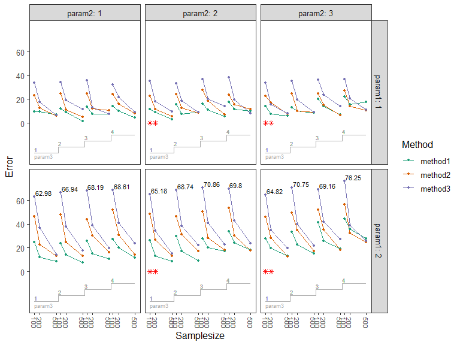

```r
p = nested_loop_base_plot(
    plot_data,
    x_name = "Samplesize",
    y_name = "Error",
    colors = scales::brewer_pal(palette = "Dark2")
) %>%
    nested_loop_paramsteps_plot(
        plot_data,
        steps_values_annotate = TRUE,
        steps_annotation_size = 2.5
    ) %>%
    add_processing(
        list(
            # annotate interesting scenarios
            add_points = list(
                mapping = aes(x = samplesize, y = annotate_scenario),
                shape = 8, color = "red", inherit.aes = FALSE
            ),
            # annotate high values
            add_text = list(
                mapping = aes(label = annotate_value),
                color = "black", size = 3, hjust = 0, vjust = 0,
                nudge_x = 20, nudge_y = 1
            ),
            # set limits
            adjust_ylim = list(
                y_expand_add = c(10, NULL)
            ),
            # adjust theme
            add_custom_theme = list(
                axis.text.x = element_text(angle = -90,
                                           vjust = 0.5,
                                           size = 8)
            )
        )
    )
print(p)
```

# References

Rücker, Gerta, and Guido Schwarzer. 2014. “Presenting Simulation Results in a Nested Loop Plot.” Journal Article. *BMC Medical Research Methodology* 14.